# predicaoEleivaoV2

Antonio Lúcio

2 de março de 2018

Carregando os dados

```r
train <- read.csv("train.csv", encoding="UTF-8")
test <- read.csv("test.csv", encoding="UTF-8")
submission <- read.csv("sample_submission.csv")
```

```r
#Pre-processamento dos dados

##Mudando os valores de NA para zero
train[is.na(train)] <- 0
test[is.na(test)] <- 0

##Retirando variáveis irrelevantes
train <- train %>% select(-ID, -nome, -numero_cadidato, -descricao_ocupacao, -estado_civil, -setor_economico_receita,
                        -setor_economico_despesa, -descricao_ocupacao)
test <- test %>% select(-ID, -nome, -numero_cadidato, -descricao_ocupacao, -estado_civil, -setor_economico_receita,
                        -setor_economico_despesa, -descricao_ocupacao)
```

#### 1. Há desbalanceamento das classes (isto é, uma classe tem muito mais instâncias que outra)? Em que proporção? Quais efeitos colaterais o desbalanceamento de classes pode causar no classificador?

Precisamos contar as instâncias das classes de situacao_final e verificar como está o balanceamento:

```r
balanceamento <- train %>% select(situacao_final) %>%
  group_by(situacao_final) %>% count(situacao_final)

hchart(balanceamento, "bar", hcaes(x = situacao_final, y = n)) %>%
  hc_xAxis(
    title = list(text = "Situação final")
    ) %>%
  hc_yAxis(
    title = list(text = "Quantidade de canditos")
  ) %>%
  hc_title(
    text = "Quantidade de candidatos que foram eleitos e não eleitos"
  )
```

[interactive chart not shown]

Como podemos observar no gráfico acima, há um desbalanceamente enorme. A quantidade de canidatos não eleitos é praticamente 10x maior do que a de eleitos. Isso interfere diretamente na acurácia dos modelos, tendo em vista que o classificador vai tender para “nao_eleito”

O pacote ROSE nos ajuda a gerar dados artificiais com base em métodos de amostragem e smoothed bootstrap.

```r
#começando com oversampling para equilibrar os dados

data_balanced_over <- ovun.sample(situacao_final ~.,
                                  data = train,
                                  method = "over",
                                  N = 7438)$data

table(data_balanced_over$situacao_final)
```

```
##
## nao_eleito     eleito
##       3719       3719
```

Agora podemos obsersar que temos a mesma proporção de eleitos e não eleitos.

```r
#agora fazendo undersampling para obter a mesma proporção.

data_balanced_under <- ovun.sample(situacao_final~.,
                                   data = train,
                                   method = "under",
                                   N = 832)$data

table(data_balanced_under$situacao_final)
```

```
##
## nao_eleito     eleito
##        416        416
```

Agora também temos a mesma proporção de eleitos e não eleitos. Porem perdemos informações significativas da amostra nestes métodos. Para isso, vamos utilizar o método “both”

```r
data_balanced_both <- ovun.sample(situacao_final~.,
                                  data = train,
                                  method = "both",
                                  p=0.5,
                                  N = 4135,
                                  seed = 1)$data

table(data_balanced_both$situacao_final)
```

```
##
## nao_eleito     eleito
##       2142       1993
```

Os dados gerados pelo excesso de amostragem prevêem a quantidade de observações repetidas. Os dados gerados pela sub-amostragem são privados de informações importantes dos dados originais. O que leva a imprecisões no resultado. Para enfrentar tal problema, ROSE também nos ajuda a gerar dados de forma sintética. Estes dados gerados usando ROSE são considerados para fornecer melhor estimativa dos dados originais.

```r
data.rose <- ROSE(situacao_final ~.,
                  data = train,
                  seed = 1)$data

table(data.rose$situacao_final)
```

```
##
## nao_eleito     eleito
##       2142       1993
```

Agora que temos o conjuntado de treino equilibrado utilizando 4 técnicas diferentes, vamos calcular o modelo e avaliar sua precisão.

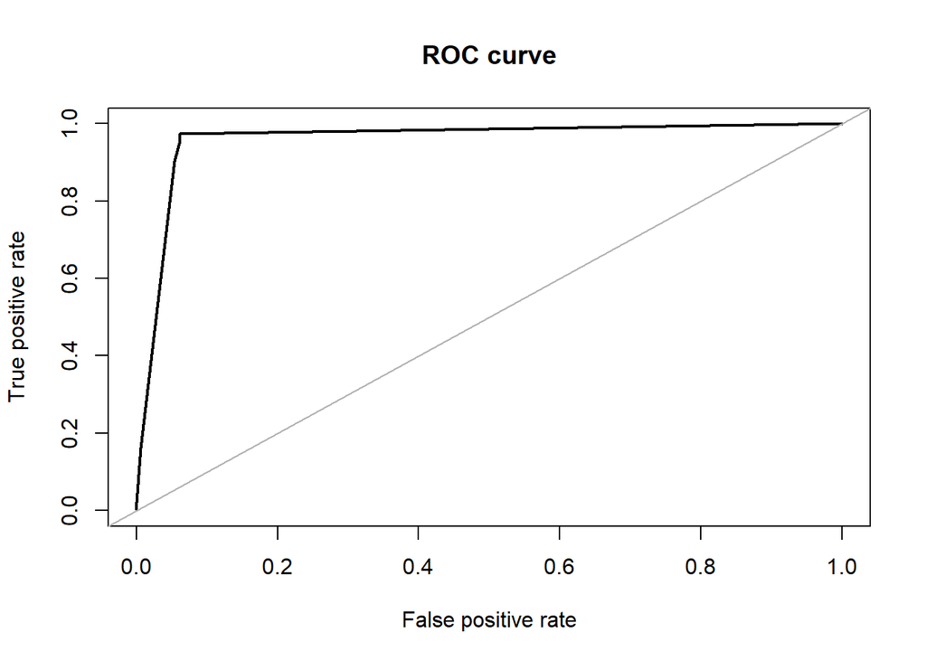

```
## Area under the curve (AUC): 0.959
```

```r
##Particionando os dados de treino em treino e teste
data.rose.partition <- createDataPartition(y = data.rose$situacao_final, p=0.75, list=FALSE)
data_balanced_over_partition <- createDataPartition(y = data_balanced_over$situacao_final, p=0.75, list=FALSE)
data_balanced_under_partition <- createDataPartition(y = data_balanced_under$situacao_final, p=0.75, list=FALSE)
data_balanced_both_partition <- createDataPartition(y = data_balanced_both$situacao_final, p=0.75, list=FALSE)

## Setando a seed para fazer a partição reproduzível
set.seed(9560)

## separando o dataframe balanceado em treino e teste

data.rose.train <- data.rose[data.rose.partition,]
data.rose.test <- data.rose[-data.rose.partition,]

data_balanced_over_train <- data_balanced_over[data_balanced_over_partition,]
data_balanced_over_test <- data_balanced_over[-data_balanced_over_partition,]

data_balanced_under_train <- data_balanced_under[data_balanced_under_partition,]
data_balanced_under_test <- data_balanced_under[-data_balanced_under_partition,]

data_balanced_both_train <- data_balanced_both[data_balanced_both_partition,]
data_balanced_both_test <- data_balanced_both[-data_balanced_both_partition,]

#construindo modelos de árvore de decisão

tree.rose <- rpart(situacao_final ~., data = data.rose.train)
tree.over <- rpart(situacao_final ~., data = data_balanced_over_train)
tree.under <- rpart(situacao_final ~., data = data_balanced_under_train)
tree.both <- rpart(situacao_final ~., data = data_balanced_both_train)

#Fazendo as predições

pred.tree.rose <- predict(tree.rose, newdata = data.rose.test)
pred.tree.over <- predict(tree.over, newdata = data_balanced_over_test)
pred.tree.under <- predict(tree.under, newdata = data_balanced_under_test)
pred.tree.both <- predict(tree.both, newdata = data_balanced_both_test)


#avaliando a precisão das predições

#ROSE
roc.curve(data.rose.test$situacao_final, pred.tree.rose[,2])
```

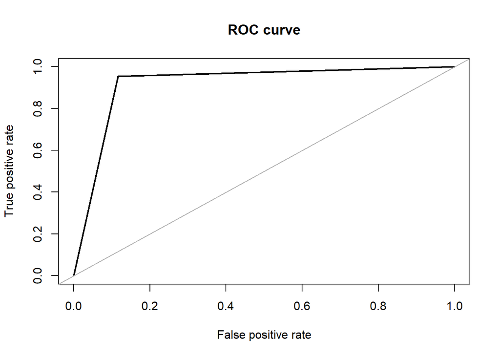

```
## Area under the curve (AUC): 0.919
```

```r
#Over
roc.curve(data_balanced_over_test$situacao_final, pred.tree.over[,2])
```

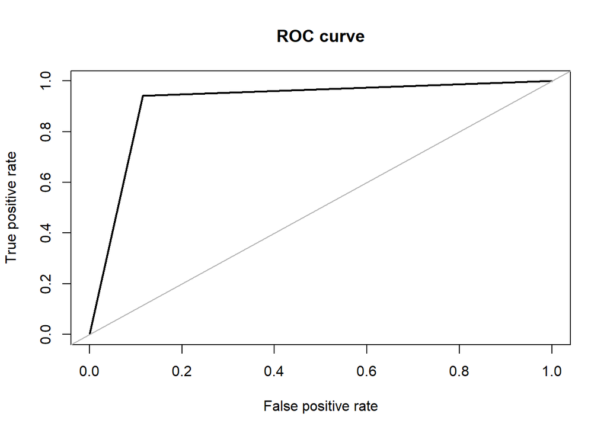

```
## Area under the curve (AUC): 0.913
```

```r
#Under
roc.curve(data_balanced_under_test$situacao_final, pred.tree.under[,2])
```

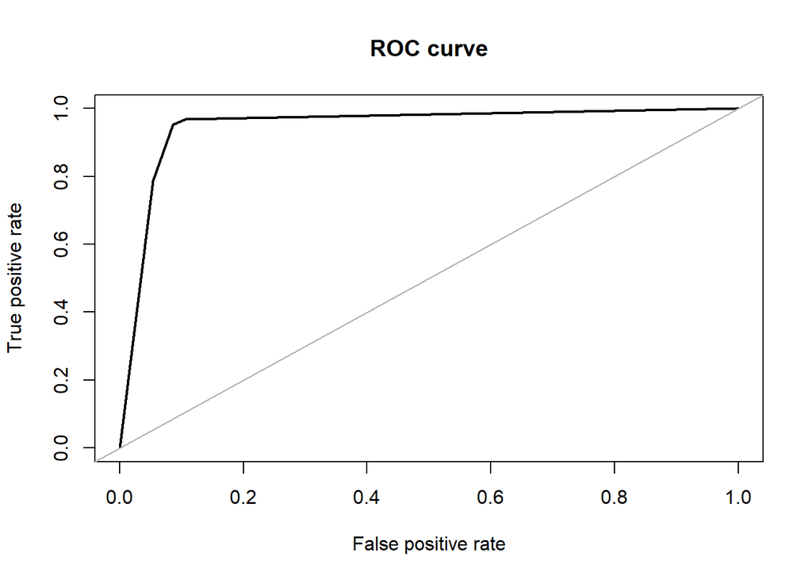

```
## Area under the curve (AUC): 0.948
```

```r
#Both
roc.curve(data_balanced_both_test$situacao_final, pred.tree.both[,2])
```

Portanto, obtemos maior precisão a partir de dados obtidos usando o algoritmo ROSE. Agora que temos o balanceamento realizado, podemos dar continuidade.

OBS: Por problemas de não conseguir resposta em tempo hábil para treinar o modelo Adaboost utilizando os dados obtidos usando o algoritmo ROSE (Passou mais de 3h rodando e não tive resposta, R usando 50% da CPU e 1GB de RAM), tive que utilizar o DF balanceado via Under, que tem menos observações e assim conseguindo obter alguma resposta (Depois de 40 minutos rodando). Por problemas de falta de hardware, tive que escolher um menos preciso.

#### Treine: um modelo de regressão logística, uma árvore de decisão e um modelo de adaboost. Tune esses modelos usando validação cruzada e controle overfitting se necessário, considerando as particularidades de cada modelo.

```r
# usando validação cruzada 10-fold com 5 repetições
fitControl <- trainControl(method = "repeatedcv",
                           number = 10,
                           repeats = 5,
                           classProbs = TRUE)

#Árvore de decisão já foi feito anteriormente


#Modelo de regressão logística
modelo.glm <- glm(formula = situacao_final ~., data=data_balanced_under_train, family="binomial")
summary(modelo.glm)
```

```
##
## Call:
## glm(formula = situacao_final ~ ., family = "binomial", data = data_balanced_under_train)
##
## Deviance Residuals:
##     Min       1Q   Median       3Q      Max
## -3.6632  -0.1867   0.0000   0.1101   2.0590
##
## Coefficients:
##                                         Estimate Std. Error z value
## (Intercept)                           -2.036e+01  5.564e+03  -0.004
## UFAL                                   1.878e+00  2.209e+00   0.851
## UFAM                                  -1.731e+00  2.811e+00  -0.616
## UFAP                                   6.217e-01  1.761e+00   0.353
## UFBA                                  -4.125e-01  1.819e+00  -0.227
## UFCE                                   4.222e-01  1.601e+00   0.264
## UFDF                                   3.384e-01  1.726e+00   0.196
## UFES                                  -1.153e+00  1.899e+00  -0.607
## UFGO                                   6.903e-01  2.131e+00   0.324
## UFMA                                   3.368e-01  1.751e+00   0.192
## UFMG                                  -5.613e-01  1.755e+00  -0.320
## UFMS                                  -3.844e+00  2.582e+00  -1.489
## UFMT                                  -7.231e+00  4.529e+00  -1.597
## UFPA                                  -1.917e+00  1.709e+00  -1.121
## UFPB                                  -5.843e-01  1.649e+00  -0.354
## UFPE                                  -9.911e-01  1.750e+00  -0.566
## UFPI                                  -3.005e+00  2.810e+00  -1.069
## UFPR                                  -9.977e-01  1.617e+00  -0.617
## UFRJ                                  -1.374e+00  1.548e+00  -0.888
## UFRN                                  -3.886e-01  2.079e+00  -0.187
## UFRO                                  -7.632e-01  2.241e+00  -0.341
## UFRR                                   2.358e+00  1.758e+00   1.341
## UFRS                                  -1.321e+00  1.613e+00  -0.819
## UFSC                                   1.132e+00  1.960e+00   0.578
## UFSE                                   1.059e+00  2.108e+00   0.502
## UFSP                                  -1.982e+00  1.583e+00  -1.252
## UFTO                                   1.811e+01  2.654e+03   0.007
## partidoPC do B                         1.191e+00  1.702e+00   0.700
## partidoPCB                            -1.333e+01  6.069e+03  -0.002
## partidoPDT                             9.235e-01  1.330e+00   0.695
```

[output cut: 132 more lines]

```
## descricao_cor_racaBRANCA               0.99784
## descricao_cor_racaINDÍGENA             0.99981
## descricao_cor_racaPARDA                0.99783
## descricao_cor_racaPRETA                0.99785
## despesa_max_campanha                   0.11365
## ---
## Signif. codes:  0 '***' 0.001 '**' 0.01 '*' 0.05 '.' 0.1 ' ' 1
##
## (Dispersion parameter for binomial family taken to be 1)
##
##     Null deviance: 865.05  on 623  degrees of freedom
## Residual deviance: 225.59  on 541  degrees of freedom
## AIC: 391.59
##
## Number of Fisher Scoring iterations: 18
```

```r
#Modelo Adaboost
modelo.ada <- caret::train(situacao_final ~.,
                data=data_balanced_under_train,
                method = "adaboost",
                trControl = fitControl)

modelo.ada
```

```
## AdaBoost Classification Trees
##
## 624 samples
##  20 predictor
##   2 classes: 'nao_eleito', 'eleito'
##
## No pre-processing
## Resampling: Cross-Validated (10 fold, repeated 5 times)
## Summary of sample sizes: 562, 561, 561, 561, 562, 562, ...
## Resampling results across tuning parameters:
##
##   nIter  method         Accuracy   Kappa
##    50    Adaboost.M1    0.9182988  0.8365719
##    50    Real adaboost  0.9247405  0.8494485
##   100    Adaboost.M1    0.9202243  0.8404176
##   100    Real adaboost  0.9240953  0.8481536
##   150    Adaboost.M1    0.9189644  0.8378980
##   150    Real adaboost  0.9221699  0.8443009
##
## Accuracy was used to select the optimal model using the largest value.
## The final values used for the model were nIter = 50 and method =
##  Real adaboost.
```

```r
#Modelo Random Forest
modelo.forest <- randomForest::randomForest(situacao_final ~.,
                                            data_balanced_under_train,
                                            ntree = 500)


modelo.forest
```

```
##
## Call:
##  randomForest(formula = situacao_final ~ ., data = data_balanced_under_train,      ntree = 500)
##                Type of random forest: classification
##                      Number of trees: 500
## No. of variables tried at each split: 4
##
##         OOB estimate of  error rate: 9.29%
## Confusion matrix:
##            nao_eleito eleito class.error
## nao_eleito        287     25  0.08012821
## eleito             33    279  0.10576923
```

#### 3. Reporte acurácia, precision, recall e f-measure no treino e validação. Como você avalia os resultados? Justifique sua resposta.

Será utilizado o modelo Adaboost para análise.

```r
data_balanced_under_test$predicao <- predict(modelo.ada, data_balanced_under_test)

# vezes que o modelo acertou na predição de que o candidato seria eleito
TP <- data_balanced_under_test %>% filter(situacao_final == "eleito", predicao == "eleito") %>% nrow()

# vezes que o modelo acertou na predição de que o candidato seria nao_eleito
TN <- data_balanced_under_test %>% filter(situacao_final == "nao_eleito" , predicao == "nao_eleito" ) %>% nrow()

# vezes que o modelo errou na predição de que o candidato seria nao_eleito
FP <- data_balanced_under_test %>% filter(situacao_final == "nao_eleito" , predicao == "eleito") %>% nrow()

# vezes que o modelo errou na predição de que o candidato seria eleito
FN <- data_balanced_under_test %>% filter(situacao_final == "eleito", predicao == "nao_eleito" ) %>% nrow()


# proporção de observações corretamente classificadas
accuracy <- (TP + TN)/(TP + TN + FP + FN)

# quantas das observaçoes preditas como positivas são realmente positivas
precision <- TP / (TP + FP)

# quantas das observaçoes positivas foram corretamente classificadas
recall <- TP / (TP + FN)

# média harmônica da precisão e recall
f_measure <- 2 * (precision * recall) / (precision + recall)

f_measure
```

```
## [1] 0.9099526
```

```r
accuracy
```

```
## [1] 0.9086538
```

```r
precision
```

```
## [1] 0.8971963
```

```r
recall
```

```
## [1] 0.9230769
```

```r
confusionMatrix(data_balanced_under_test$predicao, data_balanced_under_test$situacao_final)
```

```
## Confusion Matrix and Statistics
##
##             Reference
## Prediction   nao_eleito eleito
##   nao_eleito         93      8
##   eleito             11     96
##
##                Accuracy : 0.9087
##                  95% CI : (0.861, 0.9441)
##     No Information Rate : 0.5
##     P-Value [Acc > NIR] : <2e-16
##
##                   Kappa : 0.8173
##  Mcnemar's Test P-Value : 0.6464
##
##             Sensitivity : 0.8942
##             Specificity : 0.9231
##          Pos Pred Value : 0.9208
##          Neg Pred Value : 0.8972
##              Prevalence : 0.5000
##          Detection Rate : 0.4471
##    Detection Prevalence : 0.4856
##       Balanced Accuracy : 0.9087
##
##        'Positive' Class : nao_eleito
##
```

```r
predicao <- predict(modelo.ada, test)

for(i in 1:length(predicao)){
  submission$prediction[i] = predicao[i]
}

write.csv(submission, file = "AntonioLucioV2Predict3.csv", row.names = FALSE)
```

#### 4. Interprete as saídas dos modelos. Quais atributos parecem ser mais importantes de acordo com cada modelo? Crie pelo menos um novo atributo que não está nos dados originais e estude o impacto desse atributo.

As 10 mais importantes para o modelo de regressão logística:

```r
#Importancia das variáveis modelo de regressão logistica
impGlm <- varImp(modelo.glm)
rownames(impGlm)[order(impGlm$Overall, decreasing=TRUE)[1:10]]
```

```
##  [1] "partidoPR"          "partidoPTB"         "partidoPSD"
##  [4] "partidoPSB"         "partidoPMDB"        "partidoPHS"
##  [7] "partidoPV"          "partidoSD"          "quantidade_doacoes"
## [10] "partidoPSDB"
```

As mais importantes para o modelo Adaboost

```r
#Importancia das variáveis modelo Adaboost
varImp(modelo.ada)
```

```
## ROC curve variable importance
##
##                                       Importance
## total_despesa                            100.000
## total_receita                             99.946
## quantidade_despesas                       95.827
## quantidade_fornecedores                   93.984
## quantidade_doacoes                        92.151
## quantidade_doadores                       90.085
## recursos_de_pessoas_juridicas             87.769
## media_receita                             86.328
## recursos_de_pessoas_físicas               85.660
## recursos_de_partidos                      70.283
## media_despesa                             68.886
## recursos_de_outros_candidatos.comites     51.802
## recursos_proprios                         47.010
## despesa_max_campanha                      16.783
## grau                                      13.368
## sexo                                      10.721
## descricao_cor_raca                         8.481
## UF                                         2.836
## idade                                      1.640
## partido                                    0.000
```

As mais importantes para o modelo Random Forest

```r
#Importancia das variáveis modelo Random Forest
varImp(modelo.forest)
```

```
##                                          Overall
## UF                                     8.5892020
## partido                               12.2646343
## quantidade_doacoes                    20.3903083
## quantidade_doadores                   13.4296935
## total_receita                         59.4903531
## media_receita                         14.8465247
## recursos_de_outros_candidatos.comites  3.4923153
## recursos_de_partidos                   6.9286283
## recursos_de_pessoas_físicas           15.5108593
## recursos_de_pessoas_juridicas         17.6223722
## recursos_proprios                      4.4328363
## quantidade_despesas                   43.3312670
## quantidade_fornecedores               28.3533086
## total_despesa                         44.9225330
## media_despesa                          8.7813590
## idade                                  3.4007351
## sexo                                   0.2603285
## grau                                   1.8225994
## descricao_cor_raca                     0.6457405
## despesa_max_campanha                   2.9493631
```

As mais importantes para o modelo de arvore de decisão

```r
varImp(tree.under)
```

```
##                                         Overall
## partido                                10.19122
## quantidade_despesas                   201.72136
## quantidade_fornecedores               185.90640
## recursos_de_pessoas_físicas             5.81105
## recursos_de_pessoas_juridicas         171.85404
## total_despesa                         234.01613
## total_receita                         233.39252
## UF                                      0.00000
## quantidade_doacoes                      0.00000
## quantidade_doadores                     0.00000
## media_receita                           0.00000
## recursos_de_outros_candidatos.comites   0.00000
## recursos_de_partidos                    0.00000
## recursos_proprios                       0.00000
## media_despesa                           0.00000
## idade                                   0.00000
## sexo                                    0.00000
## grau                                    0.00000
## descricao_cor_raca                      0.00000
## despesa_max_campanha                    0.00000
```

Irei criar uma nova variável chamada isNordeste, que caso possua 1 como resposta, quer dizer que o candidato é do nordeste.

```r
data_balanced_under_train$isNordeste <- ifelse(data_balanced_under_train$UF
                                               %in% c("MA", "PI", "CE", "RN", "PB", "PE", "AL", "SE", "BA"), 1, 0)
data_balanced_under_test$isNordeste <- ifelse(data_balanced_under_test$UF
                                              %in% c("MA", "PI", "CE", "RN", "PB", "PE", "AL", "SE", "BA"), 1, 0)
```

```r
#Retreinando o modelo de regressão logística

modelo.glm.retrain <- glm(formula = situacao_final ~., data=data_balanced_under_train, family="binomial")
summary(modelo.glm.retrain)
```

```
##
## Call:
## glm(formula = situacao_final ~ ., family = "binomial", data = data_balanced_under_train)
##
## Deviance Residuals:
##     Min       1Q   Median       3Q      Max
## -3.6632  -0.1867   0.0000   0.1101   2.0590
##
## Coefficients: (1 not defined because of singularities)
##                                         Estimate Std. Error z value
## (Intercept)                           -2.036e+01  5.564e+03  -0.004
## UFAL                                   1.878e+00  2.209e+00   0.851
## UFAM                                  -1.731e+00  2.811e+00  -0.616
## UFAP                                   6.217e-01  1.761e+00   0.353
## UFBA                                  -4.125e-01  1.819e+00  -0.227
## UFCE                                   4.222e-01  1.601e+00   0.264
## UFDF                                   3.384e-01  1.726e+00   0.196
## UFES                                  -1.153e+00  1.899e+00  -0.607
## UFGO                                   6.903e-01  2.131e+00   0.324
## UFMA                                   3.368e-01  1.751e+00   0.192
## UFMG                                  -5.613e-01  1.755e+00  -0.320
## UFMS                                  -3.844e+00  2.582e+00  -1.489
## UFMT                                  -7.231e+00  4.529e+00  -1.597
## UFPA                                  -1.917e+00  1.709e+00  -1.121
## UFPB                                  -5.843e-01  1.649e+00  -0.354
## UFPE                                  -9.911e-01  1.750e+00  -0.566
## UFPI                                  -3.005e+00  2.810e+00  -1.069
## UFPR                                  -9.977e-01  1.617e+00  -0.617
## UFRJ                                  -1.374e+00  1.548e+00  -0.888
## UFRN                                  -3.886e-01  2.079e+00  -0.187
## UFRO                                  -7.632e-01  2.241e+00  -0.341
## UFRR                                   2.358e+00  1.758e+00   1.341
## UFRS                                  -1.321e+00  1.613e+00  -0.819
## UFSC                                   1.132e+00  1.960e+00   0.578
## UFSE                                   1.059e+00  2.108e+00   0.502
## UFSP                                  -1.982e+00  1.583e+00  -1.252
## UFTO                                   1.811e+01  2.654e+03   0.007
## partidoPC do B                         1.191e+00  1.702e+00   0.700
## partidoPCB                            -1.333e+01  6.069e+03  -0.002
## partidoPDT                             9.235e-01  1.330e+00   0.695
```

[output cut: 134 more lines]

```
## descricao_cor_racaINDÍGENA             0.99981
## descricao_cor_racaPARDA                0.99783
## descricao_cor_racaPRETA                0.99785
## despesa_max_campanha                   0.11365
## isNordeste                                  NA
## ---
## Signif. codes:  0 '***' 0.001 '**' 0.01 '*' 0.05 '.' 0.1 ' ' 1
##
## (Dispersion parameter for binomial family taken to be 1)
##
##     Null deviance: 865.05  on 623  degrees of freedom
## Residual deviance: 225.59  on 541  degrees of freedom
## AIC: 391.59
##
## Number of Fisher Scoring iterations: 18
```

```r
#Vendo como ficou após o retreino
impGlmRetrain <- varImp(modelo.glm.retrain)
rownames(impGlmRetrain)[order(impGlmRetrain$Overall, decreasing=TRUE)[1:10]]
```

```
##  [1] "partidoPR"          "partidoPTB"         "partidoPSD"
##  [4] "partidoPSB"         "partidoPMDB"        "partidoPHS"
##  [7] "partidoPV"          "partidoSD"          "quantidade_doacoes"
## [10] "partidoPSDB"
```

No modelo de regressão logística, a insersão da nova variável não teve impacto significativo.

```r
#retreinando o modelo Adaboost
modelo.ada.retrain <- caret::train(situacao_final ~.,
                data=data_balanced_under_train,
                method = "adaboost",
                trControl = fitControl)

modelo.ada.retrain
```

```
## AdaBoost Classification Trees
##
## 624 samples
##  21 predictor
##   2 classes: 'nao_eleito', 'eleito'
##
## No pre-processing
## Resampling: Cross-Validated (10 fold, repeated 5 times)
## Summary of sample sizes: 562, 562, 561, 561, 562, 562, ...
## Resampling results across tuning parameters:
##
##   nIter  method         Accuracy   Kappa
##    50    Adaboost.M1    0.9185194  0.8370482
##    50    Real adaboost  0.9175571  0.8351160
##   100    Adaboost.M1    0.9162514  0.8325183
##   100    Real adaboost  0.9214127  0.8428274
##   150    Adaboost.M1    0.9178491  0.8357071
##   150    Real adaboost  0.9194926  0.8389895
##
## Accuracy was used to select the optimal model using the largest value.
## The final values used for the model were nIter = 100 and method =
##  Real adaboost.
```

```r
varImp(modelo.ada.retrain)
```

```
## ROC curve variable importance
##
##   only 20 most important variables shown (out of 21)
##
##                                       Importance
## total_despesa                            100.000
## total_receita                             99.946
## quantidade_despesas                       95.827
## quantidade_fornecedores                   93.984
## quantidade_doacoes                        92.151
## quantidade_doadores                       90.085
## recursos_de_pessoas_juridicas             87.769
## media_receita                             86.328
## recursos_de_pessoas_físicas               85.660
## recursos_de_partidos                      70.283
## media_despesa                             68.886
## recursos_de_outros_candidatos.comites     51.802
## recursos_proprios                         47.010
## despesa_max_campanha                      16.783
## grau                                      13.368
## sexo                                      10.721
## descricao_cor_raca                         8.481
## isNordeste                                 4.192
## UF                                         2.836
## idade                                      1.640
```

No modelo Adaboost também não houve impacto significativo.

```r
#Retreinando modelo Random Forest
modelo.forest.retrain <- randomForest::randomForest(situacao_final ~.,
                                            data_balanced_under_train,
                                            ntree = 500)


modelo.forest.retrain
```

```
##
## Call:
##  randomForest(formula = situacao_final ~ ., data = data_balanced_under_train,      ntree = 500)
##                Type of random forest: classification
##                      Number of trees: 500
## No. of variables tried at each split: 4
##
##         OOB estimate of  error rate: 9.94%
## Confusion matrix:
##            nao_eleito eleito class.error
## nao_eleito        287     25  0.08012821
## eleito             37    275  0.11858974
```

```r
varImp(modelo.forest.retrain)
```

```
##                                          Overall
## UF                                     9.1079364
## partido                               13.3692730
## quantidade_doacoes                    18.9977772
## quantidade_doadores                   15.0120509
## total_receita                         52.9632926
## media_receita                         16.8145310
## recursos_de_outros_candidatos.comites  3.8583159
## recursos_de_partidos                   6.4244037
## recursos_de_pessoas_físicas           16.0309588
## recursos_de_pessoas_juridicas         18.0330949
## recursos_proprios                      4.4162473
## quantidade_despesas                   36.8666073
## quantidade_fornecedores               24.5713641
## total_despesa                         56.4140595
## media_despesa                          9.3222540
## idade                                  3.5991490
## sexo                                   0.2400862
## grau                                   1.6659083
## descricao_cor_raca                     0.6534206
## despesa_max_campanha                   2.7241732
## isNordeste                             0.4165258
```

Novamente vemos que não houve impacto significativo.

```r
#retreinando o modelo de árvore
tree.under.retrain <- rpart(situacao_final ~., data = data_balanced_under_train)
varImp(tree.under.retrain)
```

```
##                                         Overall
## partido                                10.19122
## quantidade_despesas                   201.72136
## quantidade_fornecedores               185.90640
## recursos_de_pessoas_físicas             5.81105
## recursos_de_pessoas_juridicas         171.85404
## total_despesa                         234.01613
## total_receita                         233.39252
## UF                                      0.00000
## quantidade_doacoes                      0.00000
## quantidade_doadores                     0.00000
## media_receita                           0.00000
## recursos_de_outros_candidatos.comites   0.00000
## recursos_de_partidos                    0.00000
## recursos_proprios                       0.00000
## media_despesa                           0.00000
## idade                                   0.00000
## sexo                                    0.00000
## grau                                    0.00000
## descricao_cor_raca                      0.00000
## despesa_max_campanha                    0.00000
## isNordeste                              0.00000
```

Conclusão: Em nenhum dos modelos houve impacto na insersão de uma nova variável